# INFS 691 - Homework8 - Part1

Text Mining and Sentiment Analysis

Rose Dunderdale

Read the document “Homework8 Instructions.docx” for detailed information about Homework 8 that has three parts.

```r
install.packages("tm")
install.packages("dplyr")
install.packages("stringr")

install.packages("wordcloud")
install.packages("wordcloud2")
install.packages("syuzhet")
install.packages("tidytext")

library(tm)  # major package for text mining
library(dplyr) # data manipulation
library(stringr) # for string-split
library(wordcloud)  # wordcloud generator
library(wordcloud2) # wordcloud2 generator
library(syuzhet) # sentiment lexicons
library(tidytext) # manipulation, sentiment
```

### Text Mining and Sentiment Analysis Process

#### Step 1. Read Data and Create Corpus

#### Step 2. Clean Data

#### Step 3. Create Term Document Matrix (tdm)

#### Step 4. Analyze Data

#### (word frequency and Sentiment Analysis)

#### Step 1. Read Text Data and Create Corpus

1. Read the text data Text data “GuderLUC691.txt” contains the actual teacher/course evaluations for the course (INFS691) that I taught at Loyola University of Chicago (LUC) in the last 3 years.

```r
text0 <- readLines("GuderLUC691.txt")
text0
```

```
  [1] "The online delivery of the course was perfect. The Professor was very organized with how he structured this course. I was never second guessing myself about where to find the resources because the professor organized the class and curriculum in an efficient manner."
  [2] "Very easy to follow and well-organized material. I liked the option to watch the lecture or just read the provided pdf with the lesson material. "
  [3] "The way this course was taught in my opinion made me learn the most from any of the courses this semester due to repetition of concepts and connecting them to the new material effectively."
  [4] "The course was structured well."
  [5] "I enjoyed that this was just a practical skill-building course. The analytical questions on the homework were helpful for understanding what the program results were telling you."
  [6] "The course was great. I learned a lot about R and Analytics"
  [7] "I enjoyed that this was just a practical skill-building course. The analytical questions on the homework were helpful for understanding what the program results were telling you."
  [8] "The course was great. I learned a lot about R and Analytics."
  [9] "There has to be a group project where you can interact with your team member and build a net"
 [10] "The instructor was very helpful. He and I (regularly) went over the Homework before submission just to make sure I was completing the assignment correctly. He was very responsive to my emails and he organized the class perfectly. I appreciate that the professor is caring and is always"
 [11] "Wonderful professor always answers his emails fast and is willing to help even if it is a question on material not associated with the course. Great resource and I am excited to be taking him next quarter."
 [12] "I really loved the way Professor Guder has structured the videos. Very well organized and I was able to complete all my homework/exams without any help."
 [13] "Professor Guder was always available to help when needed. Every time I take a class with Professor Guder, I am amazed at how well I am able to excel and learn the material despite initial hesitations on the course subject."
 [14] "He is an excellent professor and everything is presented clearly. Very organized and very structured. "
 [15] "Just due to the online nature of the class I had no real interactions with the professor. The videos were fine and easy to follow. I have got no complaints or constructive comments about him to be honest. "
```

[output cut: 181 more lines]

```r
# text0: A character vector with 196 elements.

# convert text0 to a character vector of one element (combine reviews)
text <- paste(text0, collapse=" ") # combine all in one text
text
```

```
[1] "The online delivery of the course was perfect. The Professor was very organized with how he structured this course. I was never second guessing myself about where to find the resources because the professor organized the class and curriculum in an efficient manner. Very easy to follow and well-…
```

2. Create corpus corpus is a data structure (list) that is used by the “tm” package to process and analyze text data

```r
corpus <- Corpus(VectorSource(text)) # corpus is a list of 2 elements
inspect(corpus) # or corpus$content to display the content of corpus
```

```
<<SimpleCorpus>>
Metadata:  corpus specific: 1, document level (indexed): 0
Content:  documents: 1

[1] The online delivery of the course was perfect. The Professor was very organized with how he structured this course. I was never second guessing myself about where to find the resources because the professor organized the class and curriculum in an efficient manner. Very easy to follow and well-o…
```

```r
#result: the corpus has the same content as the text vector
```

#### Step 2. Clean Data (corpus)

Purpose: to understand and analyze opinions and feelings of the customers and take actions accordingly. Cleaning: removing data/words that do not reflect any opinions or feelings.

See the corpus (before cleaning)

```r
inspect(corpus)
```

```
<<SimpleCorpus>>
Metadata:  corpus specific: 1, document level (indexed): 0
Content:  documents: 1

[1] The online delivery of the course was perfect. The Professor was very organized with how he structured this course. I was never second guessing myself about where to find the resources because the professor organized the class and curriculum in an efficient manner. Very easy to follow and well-o…
```

To clean data in corpus, we will use tm_map() function available in “tm” package

```r
# convert the text to lower case
corpus <- tm_map(corpus, tolower)
inspect(corpus) # to display the corpus
```

```
<<SimpleCorpus>>
Metadata:  corpus specific: 1, document level (indexed): 0
Content:  documents: 1

[1] the online delivery of the course was perfect. the professor was very organized with how he structured this course. i was never second guessing myself about where to find the resources because the professor organized the class and curriculum in an efficient manner. very easy to follow and well-o…
```

```r
# remove english common stopwords (is, are, this, but, and, etc.)
corpus <- tm_map(corpus, removeWords, stopwords("english"))
inspect(corpus) # to display the corpus
```

```
<<SimpleCorpus>>
Metadata:  corpus specific: 1, document level (indexed): 0
Content:  documents: 1

[1]  online delivery   course  perfect.  professor   organized    structured  course.   never second guessing     find  resources   professor organized  class  curriculum   efficient manner.  easy  follow  well-organized material.  liked  option  watch  lecture  just read  provided pdf   lesson mate…
```

```r
# remove punctuation
corpus <- tm_map(corpus, removePunctuation) #removes punctuation
inspect(corpus) # to display the corpus
```

```
<<SimpleCorpus>>
Metadata:  corpus specific: 1, document level (indexed): 0
Content:  documents: 1

[1]  online delivery   course  perfect  professor   organized    structured  course   never second guessing     find  resources   professor organized  class  curriculum   efficient manner  easy  follow  wellorganized material  liked  option  watch  lecture  just read  provided pdf   lesson material …
```

```r
# remove additional words
#specified words: professor , guder, course, class
corpus <- tm_map(corpus, removeWords, c("professor", "guder", "course", "class"))
inspect(corpus) # to display the corpus
```

```
<<SimpleCorpus>>
Metadata:  corpus specific: 1, document level (indexed): 0
Content:  documents: 1

[1]  online delivery     perfect     organized    structured     never second guessing     find  resources    organized    curriculum   efficient manner  easy  follow  wellorganized material  liked  option  watch  lecture  just read  provided pdf   lesson material   way    taught   opinion made  lea…
```

```r
# remove numbers
corpus <- tm_map(corpus, removeNumbers)
inspect(corpus)
```

```
<<SimpleCorpus>>
Metadata:  corpus specific: 1, document level (indexed): 0
Content:  documents: 1

[1]  online delivery     perfect     organized    structured     never second guessing     find  resources    organized    curriculum   efficient manner  easy  follow  wellorganized material  liked  option  watch  lecture  just read  provided pdf   lesson material   way    taught   opinion made  lea…
```

```r
# Eliminate Whitespace
corpus <- tm_map(corpus, stripWhitespace)
inspect(corpus) # to display the corpus
```

```
<<SimpleCorpus>>
Metadata:  corpus specific: 1, document level (indexed): 0
Content:  documents: 1

[1]  online delivery perfect organized structured never second guessing find resources organized curriculum efficient manner easy follow wellorganized material liked option watch lecture just read provided pdf lesson material way taught opinion made learn courses semester due repetition concepts con…
```

#### Create TWO objects: “text2” and “words”

```
(These objects will be used in Step 4 - Text analysis)
```

First object: text2 (1) text2: split the clean text (corpus) into individual elements (words) and assigns them to the vector “text2”. “Bag of words”.

```r
text2 <- str_split(corpus$content, pattern ="\\s+") # text2 is a list
text2 <- unlist(text2) #text2 is now a vector
#inspect(corpus)
text2
```

```
   [1] ""               "online"         "delivery"       "perfect"        "organized"      "structured"     "never"          "second"
   [9] "guessing"       "find"           "resources"      "organized"      "curriculum"     "efficient"      "manner"         "easy"
  [17] "follow"         "wellorganized"  "material"       "liked"          "option"         "watch"          "lecture"        "just"
  [25] "read"           "provided"       "pdf"            "lesson"         "material"       "way"            "taught"         "opinion"
  [33] "made"           "learn"          "courses"        "semester"       "due"            "repetition"     "concepts"       "connecting"
  [41] "new"            "material"       "effectively"    "structured"     "well"           "enjoyed"        "just"           "practical"
  [49] "skillbuilding"  "analytical"     "questions"      "homework"       "helpful"        "understanding"  "program"        "results"
  [57] "telling"        "great"          "learned"        "lot"            "r"              "analytics"      "enjoyed"        "just"
  [65] "practical"      "skillbuilding"  "analytical"     "questions"      "homework"       "helpful"        "understanding"  "program"
  [73] "results"        "telling"        "great"          "learned"        "lot"            "r"              "analytics"      "group"
  [81] "project"        "can"            "interact"       "team"           "member"         "build"          "net"            "instructor"
  [89] "helpful"        "regularly"      "went"           "homework"       "submission"     "just"           "make"           "sure"
  [97] "completing"     "assignment"     "correctly"      "responsive"     "emails"         "organized"      "perfectly"      "appreciate"
 [105] "caring"         "always"         "wonderful"      "always"         "answers"        "emails"         "fast"           "willing"
 [113] "help"           "even"           "question"       "material"       "associated"     "great"          "resource"       "excited"
```

[output cut: 111 more lines]

```r
#Display text2
```

Second Object: words (2) words: the list of the words in text2 vector is is expressed in a data frame structure.

```r
words <- data.frame(word=text2)
words
```

| word |
| --- |
| online |
| delivery |
| perfect |
| organized |
| structured |
| never |
| second |
| guessing |
| find |

[output cut: 990 more lines]

#### Step 3. Build a TermDocumentMatrix (tdm)

Text mining processes transforms unstructured text into a structured format (into a table/matrix) to identify meaningful patterns and new insights.

tdm turns the corpus into a document term matrix (structured data) Create tdm and the following objects: tdm_m, tdm_s, and tdm_df

```r
tdm <-TermDocumentMatrix(corpus) # tdm is a list
tdm_m <- as.matrix(tdm) # change td to matrix
tdm_m
```

```
                     Docs
Terms                  1
  ability              4
  able                 8
  accent               1
  accents              1
  access               1
  accessibility        2
  accessible           6
  accommodating        1
  accommodations       2
  accomplish           1
  actually             2
  added                1
  addition             1
  additional           6
  address              2
  advance              1
  advanced             2
  agreement            1
  ahead                2
  aids                 1
  allow                1
  allowed              1
  allows               1
  along                2
  already              4
  also                 7
  although             1
  always              15
  amazed               1
  amazing              3
  amounts              1
  ample                1
  analogies            1
  analysis             2
  analytical           4
  analytics            5
  analyze              1
  another              5
```

[output cut: 740 more lines]

```
  wonderful            3
  word                 1
  work                10
  worked               1
  working              2
  workload             2
  world                1
  worried              2
  wrap                 1
  written              1
  youtube              1
  zoom                 5
  –                    1
  ’s                   2
  “r”                  1
```

```r
# order the tdm_m matrix by decreasing value of frequencies
# and assign them to the vector "tdm_s"
tdm_s <- sort(rowSums(tdm_m), decreasing=TRUE)
tdm_s
```

```
               well               great           organized           questions            material             helpful            homework
                 38                  33                  31                  30                  29                  28                  27
           students              online              really                easy            learning           available             enjoyed
                 24                  22                  20                  18                  17                  16                  16
           provided              videos              always                help          understand               clear              follow
                 16                  16                  15                  15                  15                  14                  13
              learn                time            feedback             learned            lectures           materials                 one
                 13                  13                  12                  12                  12                  12                  12
               prof          instructor             program          responsive        asynchronous            concepts             content
                 12                  11                  11                  11                  10                  10                  10
             taking                work         appreciated                 can                good                just                 lot
                 10                  10                   9                   9                   9                   9                   9
             needed             student                take                able                best            business                made
                  9                   9                   9                   8                   8                   8                   8
                way                also           difficult            examples           extremely             subject              taught
                  8                   7                   7                   7                   7                   7                   7
                use                week          accessible          additional          appreciate            complete                data
                  7                   7                   6                   6                   6                   6                   6
          effective               email          everything               faruk             lecture                like                make
                  6                   6                   6                   6                   6                   6                   6
                mba                much             overall                pace              person          professors           recommend
                  6                   6                   6                   6                   6                   6                   6
                see              skills          statistics          structured               teach          throughout       understanding
                  6                   6                   6                   6                   6                   6                   6
          analytics             another             courses              emails           excellent        expectations                feel
                  5                   5                   5                   5                   5                   5                   5
                get              helped               hours            interact                 job               liked               loved
                  5                   5                   5                   5                   5                   5                   5
             office         opportunity           presented         programming             quickly               sakai               since
                  5                   5                   5                   5                   5                   5                   5
              taken            teaching               thank              topics            whenever                zoom             ability
                  5                   5                   5                   5                   5                   5                   4
            already          analytical             clearly                 due         effectively                find                hard
                  4                   4                   4                   4                   4                   4                   4
              level              little              manner             modules            multiple               needs            optional
                  4                   4                   4                   4                   4                   4                   4
           possible              posted             quarter            question               quick               quite            recorded
                  4                   4                   4                   4                   4                   4                   4
          resources           sometimes             success               tests               think               times                 via
                  4                   4                   4                   4                   4                   4                   4
```

[output cut: 173 more lines]

```
                  1                   1                   1                   1                   1                   1                   1
           tangible                term               terms                test              things          thoroughly              though
                  1                   1                   1                   1                   1                   1                   1
           thursday              timely                tool               tough              toward             towards          transition
                  1                   1                   1                   1                   1                   1                   1
       transitioned             trouble              trying              turned                 two         understands            uploaded
                  1                   1                   1                   1                   1                   1                   1
              upper        userfriendly           utilizing            vehicles           virtually              visual              wanted
                  1                   1                   1                   1                   1                   1                   1
            wanting            watching       wellorganized            wherever              whilst               whole         willingness
                  1                   1                   1                   1                   1                   1                   1
             within                word              worked               world                wrap             written             youtube
                  1                   1                   1                   1                   1                   1                   1
                  –                 “r”
                  1                   1
```

```r
# tdm_s is a vector
# convert the tdm_s vector into a data frame format (tdm_df)
# with the column names as follows:
# column1 is named as 'word', column2 is named as 'freq'
# This is needed only if you wanted to display wordcloud2 in step 4
tdm_df <- data.frame(word = names(tdm_s), freq=tdm_s)
tdm_df
```

|  | word | freq |
| --- | --- | --- |
| well | well | 38 |
| great | great | 33 |
| organized | organized | 31 |
| questions | questions | 30 |
| material | material | 29 |
| helpful | helpful | 28 |
| homework | homework | 27 |
| students | students | 24 |
| online | online | 22 |
| really | really | 20 |

[output cut: 783 more lines]

#### Step 4. Analyze Text Data

1. Visual Display of word frequencies using wordcloud
2. Visual Display of word frequencies using barplot
3. Sentiment Analysis - calculate sentiments (customer opinions)

#### (1) Display word frequencies using wordcloud

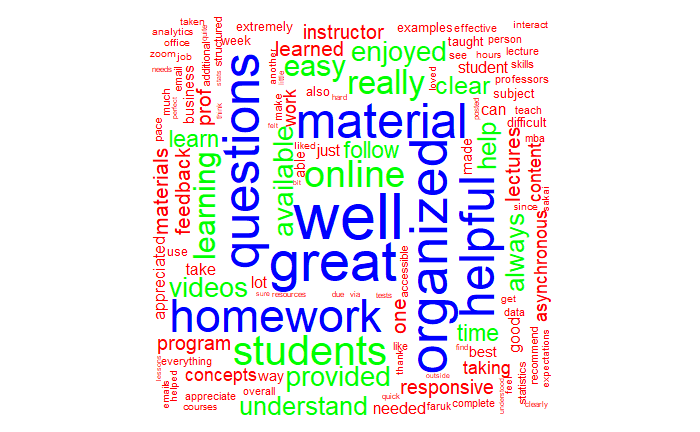

```r
# wordcloud (corpus)
set.seed(123)        # to obtain the same display
wordcloud(corpus,    #clean corpus
         max.words=150,  # max number of words
         min.freq=1,     # words with the frequency below will not be plotted
         random.order=F, # the words displayed in random order
         color=rainbow(3),  # rainbow color option
         scale=c(4.0,0.1),  # the range of the size of the words
         rot.per=0.30)      # proportion of the words to be rotated
```

Another package - wordcloud2 Using wordcloud2

```r
set.seed(123)
wordcloud2(tdm_df,
           size=0.6,
           color=rainbow(5),
           shape="oval",
           rotateRatio=0.3)
```

[interactive chart not shown]

#### (2) Display word frequencies using a barplot

Display barplot for the top 15 most frequent words

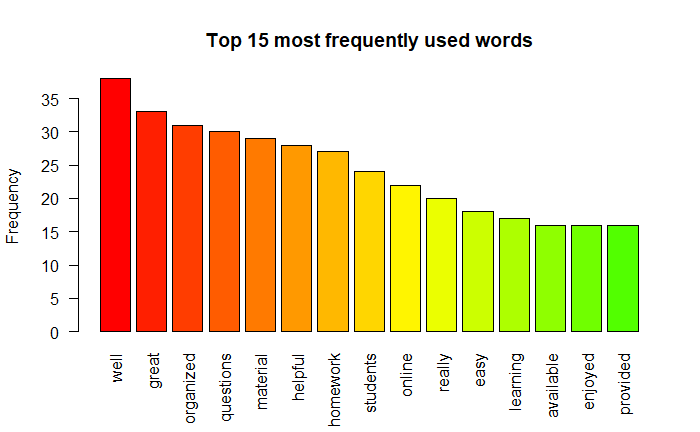

```r
# using the tdm_s: sorted tdms_s matrix
barplot(head(tdm_s,15),    # the object should be a (sorted) vector
        las=2,
        col=rainbow(50),
        ylab="Frequency",
        main= "Top 15 most frequently used words")
```

#### (3) Sentiment Analysis

# sentiment analysis = the process of determining whether a text is posituve,

# negative or neutral

#### Sentiment Scores using “bing” lexicon, which categorizes words into

# positive and negative categories

#### Read the lexicon by bing: list of positive and negative terms

Pull out only sentiment words. #### Read the sentiment words in the “bing” lexicon:

```r
bing <- get_sentiments(lexicon="bing") # from tidytext package
bing                                   # list of word in bing lexicon - 6786 words
```

| word | sentiment |
| --- | --- |
| 2-faces | negative |
| abnormal | negative |
| abolish | negative |
| abominable | negative |
| abominably | negative |
| abominate | negative |
| abomination | negative |
| abort | negative |
| aborted | negative |
| aborts | negative |

[output cut: 990 more lines]

```r
words                                  # list of (bag) words in clean opus -
```

| word |
| --- |
| online |
| delivery |
| perfect |
| organized |
| structured |
| never |
| second |
| guessing |
| find |

[output cut: 990 more lines]

```r
                                       ## created in step 2
```

#### Determine the sentiment words in our text (corpus)

```r
text_bing <- inner_join(words, bing, by="word")
text_bing   # list of all sentiment words in clean corpus
```

| word | sentiment |
| --- | --- |
| perfect | positive |
| efficient | positive |
| easy | positive |
| liked | positive |
| effectively | positive |
| well | positive |
| enjoyed | positive |
| helpful | positive |
| great | positive |
| enjoyed | positive |

[output cut: 443 more lines]

Separate the list of the positive an negative words

```r
poswords <- subset(text_bing, sentiment=="positive")
negwords <- subset(text_bing, sentiment=="negative")
poswords    # display the positive words
```

|  | word | sentiment |
| --- | --- | --- |
| 1 | perfect | positive |
| 2 | efficient | positive |
| 3 | easy | positive |
| 4 | liked | positive |
| 5 | effectively | positive |
| 6 | well | positive |
| 7 | enjoyed | positive |
| 8 | helpful | positive |
| 9 | great | positive |
| 10 | enjoyed | positive |

[output cut: 388 more lines]

```r
negwords    # display the negative words
```

|  | word | sentiment |
| --- | --- | --- |
| 33 | complaints | negative |
| 44 | hard | negative |
| 47 | slow | negative |
| 48 | dense | negative |
| 54 | lost | negative |
| 57 | trouble | negative |
| 67 | stressful | negative |
| 85 | regret | negative |
| 87 | difficulties | negative |
| 91 | breaking | negative |

[output cut: 45 more lines]

Count the number of positive and negative and calculate the sentiment score for the text.

```r
countPos <- nrow(poswords)    # count the number of positive words
countNeg <- nrow(negwords)    # count the number of negative words
countPos
```

```
[1] 398
```

```r
countNeg
```

```
[1] 55
```

```r
# Calculate sentiment score (sentiment score = countPos - countNeg)
result <- c(positive=countPos, negative=countNeg, sentimentsScore=countPos - countNeg)
result
```

```
       positive        negative sentimentsScore
            398              55             343
```

This sentiment score indicates a very strong positive review by the students

### Note about the sentiment scores

The # of positive and negative sentiments, and the sentiment score depends on the number of reviews.

The # of the positive and negative words tend to increase together for a longer review. Therefore, it might be helpful to use the ratios of positive and negative word counts if you are comparing the sentiment scores for 2 different products or services with different number of reviews (texts), it might be helpful to use the ratios of the number of positive and negative words.

### results review

Degree of positivity/negativity = countPos/(countPos + countNeg)

Degree of positive = 398/453 = 87.86%, meaning that 87.86% of the sentiment words in the reviews are positive. This is a high percenttage of positive words.

OR

Degree of positivity = countPos/countNeg

Thsi ratio is an example equal to 398/55 = 7.24, meaning that the reviews in this example included 7.24 positive words for each negative word. Again, this ratio indicates a very strong positive sentiment.

#### Create the html file and submit it on Sakai

You need to create the html file: After completing your Rmd file, you will execute all the chunks, save the file, and generate the html file containing the codes, outputs, and the answers.

To create the html file, complete the following steps:

Step 1. (After writing all the codes) Execute all chunks one by one starting from the first chunk (regardless of whether you executed the codes while writing your codes).

Step 2. Save your file->Save As…

If you have completed Step 1, then Step 2 will save your Rmd file, and (at the same time) it will create the html file on your working directory. You will attach and submit this html file on Sakai as your homework8-Part1.

Important: Please check the html file to make sure that it contains the R codes, outputs, and your answers. If not, repeat Step 1 and Step 2.